← AN05B023b/c scenes

# AN05B023b/c: sensory drive and downstream partners

## Setup

`rgl` cannot initialise headless on this machine, so `rgl.useNULL` is set before anything that might pull it in.

Everything that fetches or draws lives in `_an_pair.R`, shared with `07_an05b023cd.Rmd` so the two comparisons cannot drift apart. What stays here is the pair and what is said about it.

```r
options(rgl.useNULL = TRUE)   # must precede any library that pulls rgl in (nat)

suppressMessages({
  library(neuprintr); library(malecns); library(nat)
  options(malecns.dataset = "male-cns:v1.0")   # malecns helpers ignore MCNS_DATASET
  library(coconatfly); library(coconat)
  library(dplyr); library(tibble)
  library(ggplot2); library(ggrepel); library(scales); library(patchwork)
})

R_DIR <- "/Users/fkampf/Documents/pheromone.paper/analyses/an_investigation/R"

# _paths.R falls back to an05b023bc, but AN_CASE may already be set to another
# case from an earlier 01-03 run in this session, so pin it here.
Sys.setenv(AN_CASE = "an05b023bc")
source(file.path(R_DIR, "_paths.R"))
source(file.path(R_DIR, "_an_pair.R"))
neuprint_login(server = MCNS_SERVER, dataset = MCNS_DATASET)

PAIR <- TARGET_TYPES   # left of zero, right of zero
PAIR
```

```
## [1] "AN05B023b" "AN05B023c"
```

Annotation tables are expensive to fetch, so they are cached in the global environment for the session.

```r
load_once <- function(name, expr, envir = .GlobalEnv) {
  # eval() here evaluates a quote()d expression written literally in this file -
  # it is a lazy-evaluation idiom for "only run this fetch if not already cached",
  # not a parser of external input.
  if (!exists(name, envir = envir, inherits = FALSE)) {
    assign(name, eval(expr), envir = envir)
  }
  get(name, envir = envir)
}
# No BANC here: this page is a maleCNS-only follow-up. For a BANC cross-check,
# copy the guarded fct / fba block from 04_SN_AN_connections.Rmd (lines 48-65) -
# reticulate::py_require("caveclient") has to run before python initialises.

mba <- load_once("mba", quote(mcns_body_annotations()))
```

## The sensory pool

Leg and wing gustatory bristle neurons. Wider than the receptor-typed set on purpose: the generic taste bristles act as a built-in negative control, so if the pheromone candidates fail to separate from them that is itself a result.

`sensory_pool()` drops bodies with no type, both `NA` and `""` — neuprint returns the empty string, which is why `load_mba()` in `pheromone.paper/R/data_processing.R` converts it, and these pages fetch from neuprint rather than from `mba.feather`.

Consequence of that same choice: `type` here is the bare server name, so the `_ADMN` / `_ProLN` suffix variants documented in `_paths.R` do **not** appear and `bare_type()` is a no-op on this table. Read `mba.feather` instead if the suffix split matters.

```r
contact_pool <- sensory_pool(mba)

length(contact_pool)
```

```
## [1] 1067
```

## Downstream output of each type

`mcns_connection_table(..., 'o')` puts the query body in `bodyid` and the partner in `partner`; its `type` column describes the **partner**, so grouping on `type` already gives the postsynaptic type. Dropping partners that are in `contact_pool` removes the sensory bristles, leaving the genuinely downstream side — and the sensory section below keeps exactly what this one discards.

```r
l_output <- type_edges(paste0("/type:", PAIR[1]), "o", contact_pool)
r_output <- type_edges(paste0("/type:", PAIR[2]), "o", contact_pool)

setNames(c(sum(l_output$total), sum(r_output$total)), PAIR)
```

```
## AN05B023b AN05B023c
##      4842      9494
```

## b vs c: difference

Both types are two bodies (one per side, both GABAergic), so the raw weight totals are directly comparable and no per-cell scaling is needed. The two overall output totals printed above are the caveat to watch: if one type makes substantially more synapses than the other, every bar shifts in its direction, so read `frac_diff` (each partner’s share of that type’s own downstream output) alongside `diff` before calling a partner type specific.

`diff_of()` full-joins the two, so partners seen by only one become 0 on the other side rather than dropping out, which is exactly the case the plot is for.

```r
out_diff <- diff_of(l_output, r_output)

out_diff |> select(type, total_l, total_r, diff, frac_diff)
```

| type | total_l | total_r | diff | frac_diff |
| --- | --- | --- | --- | --- |
| AN05B023c | 464 | 6 | -458 | -9.519619e-02 |
| AN05B023d | 469 | 36 | -433 | -9.306893e-02 |
| ANXXX093 | 434 | 13 | -421 | -8.826310e-02 |
| AN05B102b | 421 | 5 | -416 | -8.642089e-02 |
| DNpe029 | 178 | 0 | -178 | -3.676167e-02 |
| IN00A048 | 171 | 24 | -147 | -3.278807e-02 |
| IN05B011a | 149 | 22 | -127 | -2.845516e-02 |
| AN09B017e | 122 | 5 | -117 | -2.466955e-02 |
| AN05B102c | 119 | 16 | -103 | -2.289135e-02 |
| AN05B097 | 102 | 1 | -101 | -2.096035e-02 |

[output cut: 710 more lines]

The bars run bottom to top, most b-biased (negative) to most c-biased (positive). `MIN_DIFF` only controls readability — with every partner type on one axis the labels are unreadable — so the count of types it hides is printed rather than left implicit.

```r
MIN_DIFF <- 20   # synapses; a type must differ by at least this to get a bar

shown <- out_diff |> filter(abs(diff) >= MIN_DIFF)
sprintf("%d of %d partner types shown; %d hidden below |diff| = %d",
        nrow(shown), nrow(out_diff), nrow(out_diff) - nrow(shown), MIN_DIFF)
```

```
## [1] "109 of 720 partner types shown; 611 hidden below |diff| = 20"
```

A difference says nothing about scale on its own: 300 synapses is the whole story on a partner that receives 800 inputs and a rounding error on one that receives 20,000. The right-hand panel carries that. It is fetched only for the types that survive `MIN_DIFF`, which is what keeps this from being the slow all-partners call, and it is edge weights again, so it is on the same footing as the bars.

The dimorphism colours are deliberately a different hue family from the blue/pink pair colours: purple for male-specific, teal for sexually dimorphic, pale for the “potentially” calls, grey for unannotated. Nothing about a colour here should read as bias toward b or c.

```r
bars_out <- bars_downstream(shown, mba)

count(bars_out, grp)
```

| grp | n |
| --- | --- |
| male-specific | 12 |
| potentially male-specific | 1 |
| sexually dimorphic | 2 |
| potentially sexually dimorphic | 2 |
| not annotated | 92 |

The absolute counts go on top of the difference bars as one line per row: its left end is how many synapses AN05B023b gives that partner, its right end how many AN05B023c gives it. Both ends are plotted as positive counts, b mirrored to the left of zero, so the x axis reads outward from the centre in both directions and the tick labels are `abs()`.

The bar and the line are the same two numbers seen two ways: the line’s midpoint sits at half the difference, so a line centred on zero is a partner both neurons drive equally, however long it is.

One consequence of sharing an axis: partners with thousands of synapses stretch the scale and squash the difference bars. That is the honest relationship between the two quantities, but if the bars become unreadable, drop the line onto its own panel instead.

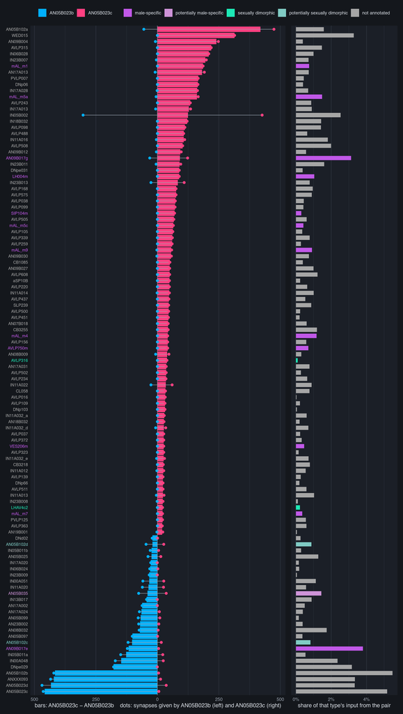

```r
bc_plot(bars_out,
        pair      = PAIR,
        lab_cols  = unname(DIMORPH_COLS[as.character(bars_out$grp)]),
        grp_cols  = DIMORPH_COLS,
        x_lab     = sprintf("bars: %s − %s    dots: synapses given by %s (left) and %s (right)",
                            PAIR[2], PAIR[1], PAIR[1], PAIR[2]),
        share_lab = "share of that type's input from the pair")
```

## Output onto dimorphic partners

Which of the two sends more of its output to partners the dataset calls dimorphic or sex-specific. Computed on `out_diff`, the whole downstream table rather than the `MIN_DIFF` subset, because this is a property of each type’s entire output and thresholding first would drop the tail where an annotated class can hide.

`frac_l` / `frac_r` are shares of that type’s own total, so “more” here survives one of the two simply being the bigger neuron.

```r
dimorph_out <- dimorph_output(out_diff, mba)

dimorph_out
```

| dimorphism | types | total_l | total_r | frac_l | frac_r |
| --- | --- | --- | --- | --- | --- |
| male-specific | 53 | 244 | 1150 | 0.0503923998 | 0.121129134 |
| potentially male-specific | 1 | 76 | 36 | 0.0156959934 | 0.003791869 |
| sexually dimorphic | 7 | 2 | 74 | 0.0004130525 | 0.007794396 |
| potentially sexually dimorphic | 7 | 177 | 57 | 0.0365551425 | 0.006003792 |
| not annotated | 652 | 4343 | 8177 | 0.8969434118 | 0.861280809 |

Total share onto annotated partners, per type:

```r
setNames(colSums(dimorph_out[dimorph_out$dimorphism != "not annotated",
                             c("frac_l", "frac_r")]), PAIR)
```

```
## AN05B023b AN05B023c
## 0.1030566 0.1387192
```

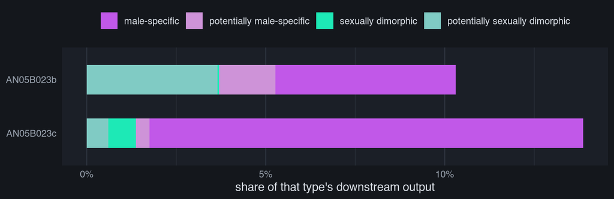

```r
dimorph_output_plot(dimorph_out, PAIR)
```

Read the bar lengths first — that is the answer to “which one” — and the segments only for which class carries it. Note that `not annotated` is the majority class in `mba`, so both bars are short by construction; the comparison is between them, not against 100%.

## Sensory input to b and c

The mirror image of the plot above, on the types that `type_edges()` excluded there: the leg and wing gustatory bristles of `contact_pool`. Left end of each line is what that bristle type gives AN05B023b, right end what it gives AN05B023c, and the bar is still c − b.

```r
l_input <- type_edges(paste0("/type:", PAIR[1]), "i", contact_pool, sensory = TRUE)
r_input <- type_edges(paste0("/type:", PAIR[2]), "i", contact_pool, sensory = TRUE)

in_diff <- diff_of(l_input, r_input)

in_diff |> select(type, total_l, total_r, diff, frac_diff)
```

| type | total_l | total_r | diff | frac_diff |
| --- | --- | --- | --- | --- |
| LgLG1a | 6781 | 250 | -6531 | -0.4881141073 |
| WG4 | 4346 | 185 | -4161 | -0.3089296611 |
| LgLG6 | 342 | 1 | -341 | -0.0264488000 |
| LgLG5 | 156 | 1 | -155 | -0.0119785962 |
| WG1 | 91 | 10 | -81 | -0.0055024700 |
| LgLG7 | 80 | 0 | -80 | -0.0062237436 |
| LgLG2 | 45 | 8 | -37 | -0.0022392251 |
| SNxxxx | 14 | 8 | -6 | 0.0001724755 |
| LgLG8 | 3 | 0 | -3 | -0.0002333904 |
| SNch05 | 16 | 20 | 4 | 0.0019093279 |

[output cut: 4 more lines]

No dimorphism colours on this one: every body in the pool is unannotated for `dimorphism`, so that scale would come out uniformly grey. `subclass` is what the pool does carry, so the second panel is filled by leg versus wing bristle.

The four FOCUS types are picked out in bold rather than in `WEB_PALETTE`: that palette gives `LgLG1a` the same pink and `LgLG1b` the same blue that already mean c and b in this plot, so using it on the labels would put two meanings on one colour. Types are named as the connectome names them, so no receptor-channel grouping is implied.

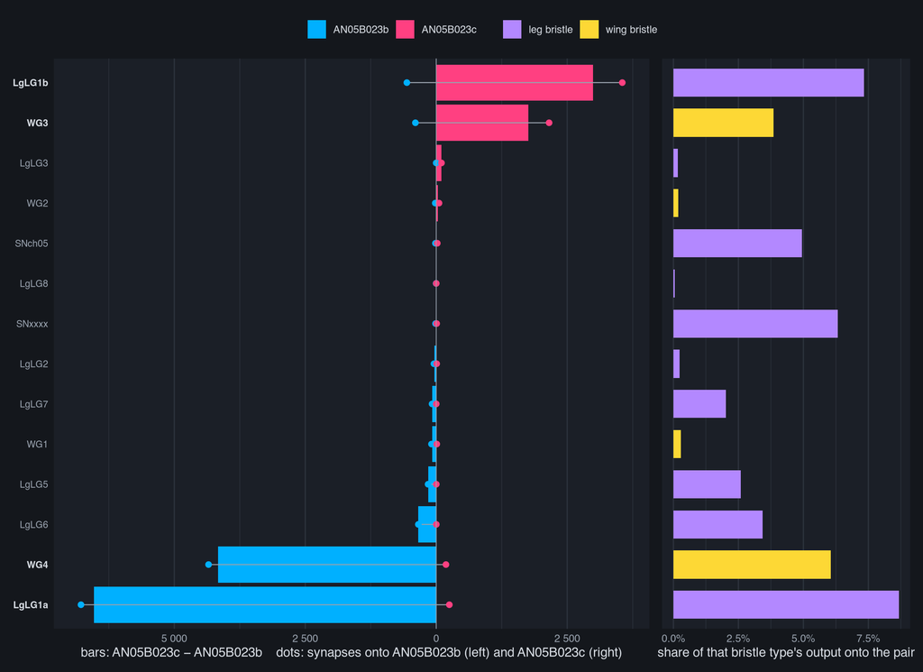

```r
bars_in <- bars_sensory(in_diff, mba, contact_pool)

is_focus <- as.character(bars_in$type) %in% FOCUS

bc_plot(bars_in,
        pair      = PAIR,
        lab_cols  = ifelse(is_focus, DARK_FG, DARK_DIM),
        grp_cols  = SUBCLASS_COLS,
        x_lab     = sprintf("bars: %s − %s    dots: synapses onto %s (left) and %s (right)",
                            PAIR[2], PAIR[1], PAIR[1], PAIR[2]),
        share_lab = "share of that bristle type's output onto the pair",
        lab_face  = ifelse(is_focus, "bold", "plain"))
```